# 5003_Final_Report

W04G06

The following content is provided by `W04G06` based on the **“Credit score classification”** dataset available on **Kaggle**. It is intended solely for educational and learning purposes, and does not include verified real-world data sources.

## 1. Problem Overview

In today’s world, credit payment is an important part of modern consumer behavior. It provides consumers with more optional payment schemes and is widely used in house purchase, car purchase, and other daily transaction activities. However, while credit payment brings many conveniences to consumers, it also poses inevitable risks to financial institutions such as commercial banks. Because of this, credit ratings are widely used. They help financial institutions dynamically identify high-risk customers, avoid over-crediting them, or reject providing loans to them, thereby reducing potential bad debt losses. Credit ratings can also assist in implementing differentiated pricing and hierarchical marketing strategies. For example, offering low interest rates and high credit limits to users with good credit, and charging higher interest rates or service fees to users with poor credit to cover potential risk costs. In these ways, credit ratings enable financial institutions to optimize the efficiency of capital use. Since financial institutions are generally required to set aside provisions to cover potential losses, the reserve ratio for high-quality loans is lower than that for subprime loans. Increasing the proportion of high-quality loans can reduce the capital occupation of financial institutions. Therefore, we aim to build classification models to accurately classify the credit ratings of customers based on their credit-related information collected in the dataset.

## 2. Dataset Overview

The dataset used in this project was sourced from Kaggle (https://www.kaggle.com/datasets/parisrohan/credit-score-classification) and is released under the CC0:Public Domain license. While no official source or publication is provided, we assume it is synthetic and used for educational purposes only. It includes **12 categorical features** and **16 numerical features**, containing credit-related information and some bank details.

The dataset had a significant amount of missing values, unaligned fields, and inconsistent entries. We handled these issues by either replacing them with actual data or removing affected rows, as the dataset size was sufficiently large.

Our dataset meets **three major challenges**: **Large size** (100,000 observations), **Missingness** (requiring extensive cleaning and preprocessing, and **Multi-class classification** (the target variable **Credit_Score** consisting of **three categories**: `Good`, `Standard`, and `Poor`).

### 2.2 Data Cleaning

During the data cleaning process, we adopted multiple imputation strategies for missing values:

- For most **numeric variables** (such as `Monthly_Inhand_Salary`, `Num_Credit_Inquiries`, `Monthly_Balance`, etc.), we used the **median** to fill missing values. This avoids the influence of outliers on the mean and improves model stability.
- The placeholder `'_'` in **categorical variables** such as `Credit_Mix` was replaced with the most frequent category.
- For `Occupation`, we grouped and filled missing values using the **mode** in combination with the historical records of each customer to maintain consistency within the same customer’s data.
- The variable `Credit_History_Age` was parsed into months, and missing values were filled with the **median** to ensure comparability in the time dimension.

In terms of **outlier handling**:

- All numeric variables (except `Age`) were evaluated using the **IQR method**. Any value exceeding **1.5 times the interquartile range** from the upper or lower quartile was treated as an outlier, and the corresponding row was removed.
- For `Age`, we applied domain knowledge and limited valid values between `1` and `100`. Records outside this range were also treated as exceptions.

This strategy, which combines statistical methods with domain-informed rules, effectively improved data quality and enhanced the robustness of the model.

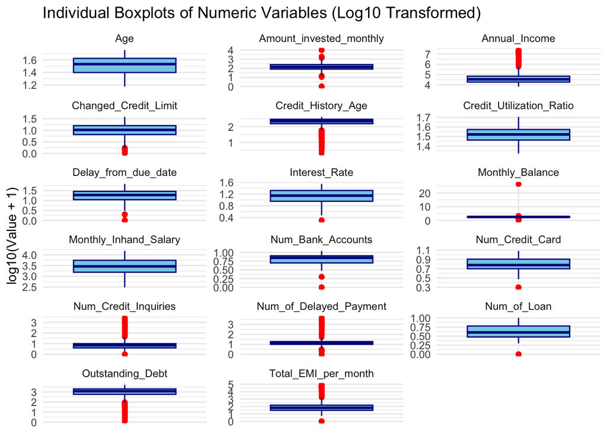

### 2.3 Preprocessing

Before modeling, we applied unified preprocessing procedures to the cleaned dataset to facilitate subsequent model training and avoid redundant preprocessing steps. First, we removed `Customer_ID` and `Month`, which are not directly related to the prediction task, in order to prevent irrelevant features from interfering with the model’s decision-making.

The dataset was then split into training and test sets using an `80/20` stratified split with the `createDataPartition` function. This ensured that the class distribution of the target variable `Credit_Score` remained consistent across both sets, enhancing the fairness of model evaluation.

For the training set:

- The target variable `Credit_Score` was extracted and converted to a factor.
- Categorical features were one-hot encoded using the `dummyVars` function from the **caret** package, transforming them into a numerical format suitable for modeling.
- All features were standardized using z-score normalization (i.e., centering and scaling), ensuring that each variable contributes equally to the model.

To prevent data leakage, the one-hot encoder and scaler were fitted using only the training set, and then applied to the test set using the same parameters.

Since different models have varying requirements for input data:

- **Support Vector Machine** required both one-hot encoding and standardization.
- **Multinomial Logistic Regression** only required standardization.
- Tree-based models (like **Extreme Gradient Boosting**) do not require either transformation.

We applied model-specific preprocessing strategies accordingly. Additionally, since tree-based models and linear models differ significantly in how they interact with resampling and feature selection techniques, we handled them separately during model training to maximize their respective performance.

```r
df <- read_csv("train_cleaned_final.csv")

#Drop irrelevant columns
df <- df %>%
  dplyr::select(-c(Customer_ID, Month))

#Split data into training and test sets (80/20 stratified split)
set.seed(5003)
train_index <- createDataPartition(df$Credit_Score, p = 0.8, list = FALSE)
df_train <- df[train_index, ]
df_test  <- df[-train_index, ]

#Separate features and target for training set
y_train <- as.factor(df_train$Credit_Score)
X_train <- df_train %>% dplyr::select(-Credit_Score)

#One-hot encode categorical variables on training data
X_encoder <- dummyVars("~ .", data = X_train)
X_train_encoded <- predict(X_encoder, newdata = X_train) %>% as.data.frame()

#Standardize training data
preproc <- preProcess(X_train_encoded, method = c("center", "scale"))
X_train_scaled <- predict(preproc, newdata = X_train_encoded)

#Prepare test set: same encoding and scaling
X_test <- df_test %>% dplyr::select(-Credit_Score)
y_test <- as.factor(df_test$Credit_Score)

X_test_encoded <- predict(X_encoder, newdata = X_test) %>% as.data.frame()
X_test_scaled <- predict(preproc, newdata = X_test_encoded)

#Processing for MLR(only use standardization)
preproc_mlr <- preProcess(X_train, method = c("center", "scale"))
X_train_scaled_mlr <- predict(preproc_mlr, newdata = X_train)
X_test_scaled_mlr <- predict(preproc_mlr, newdata = X_test)
factor_vars <- c("Occupation", "Credit_Mix",
                 "Payment_of_Min_Amount", "Payment_Behaviour")
X_train_scaled_mlr[factor_vars] <- lapply(X_train_scaled_mlr[factor_vars], as.factor)
X_test_scaled_mlr[factor_vars] <- lapply(X_test_scaled_mlr[factor_vars], as.factor)
```

## 3. Exploratory Data Analysis

### 3.1 Variable Overview and Statistical Association with Target

To begin, we import and summarize the cleaned dataset. This step provides a general understanding of the data shape, data types, and the ranges of each feature. The overview helps identify the presence of categorical versus numerical variables.

After cleaning and preparing, the number of numeric variables is 17, and that of categorical variables is 5. Further exploration and visualization are based on these variables.

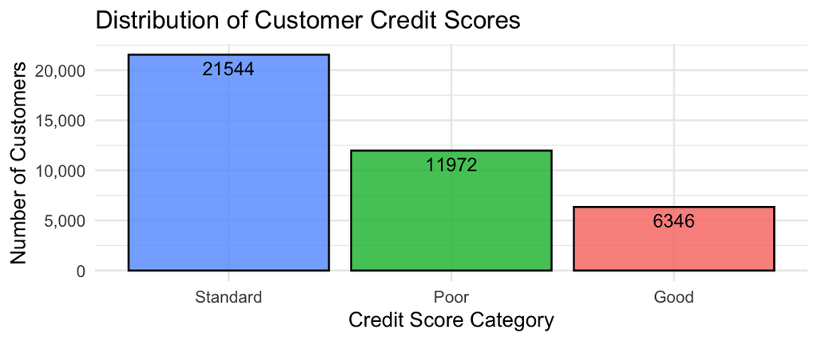

Customers’ credit_score is the classification target. The distribution of customer credit scores displays three categories: Standard, Poor, and Good. There’s a notable class imbalance, for 21544 records are Standard score. Poor credit scores account for 11972 customers, while 6346 records are Good.

**Output**

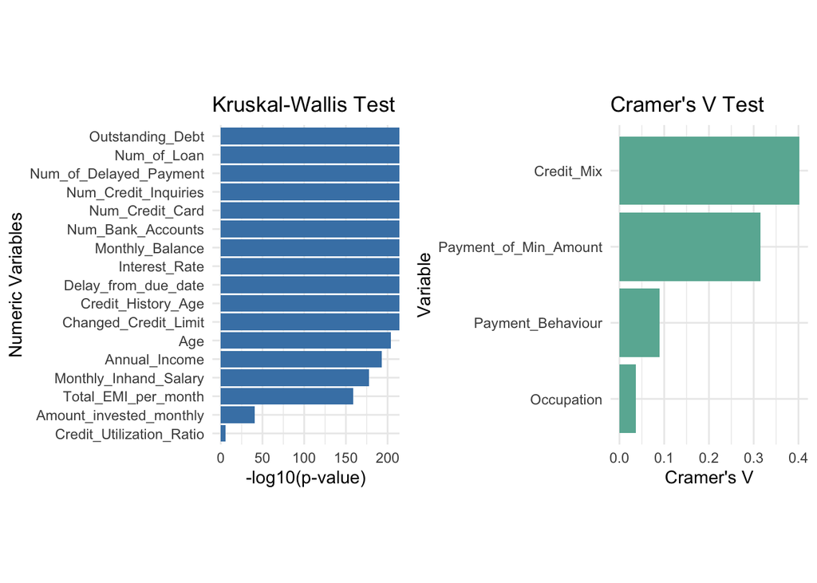

The left chart presents the **statistical association strength** between each numerical variable and the `Credit_Score` categories based on the `kruskal.test()` (Kruskal-Wallis test). Output shows `p-values` from Kruskal-Wallis tests comparing each numerical variable across credit score groups. A `p-value` near `0` indicates a statistically significant difference, meaning that variable varies meaningfully by credit score and can be used in further modelling.

The right bar chart presents the **strength of association** between the selected categorical variables and `Credit_Score` using **Cramér’s V**. Among the variables, `Credit_Mix` and `Payment_of_Min_Amount` show the **strongest relationships** with credit score classification, suggesting their **high predictive value**. In contrast, `Occupation` exhibits **relatively low association**, indicating it may contribute less in modeling unless enhanced or re-encoded.

### 3.2 Insight and Conclusion

For numerical variables, we evaluate their statistical significance with the target variable using the `kruskal.test()` (Kruskal-Wallis test). Variables with small *p*-values (e.g., `Outstanding_Debt`, `Num_of_Loan`) are retained, while less informative ones can be excluded or reconsidered. For models like **Logistic Regression**, **k-NN**, **SVM**, and **LDA/QDA**, numeric variables should be standardized using `scale()` to ensure uniform contribution. Categorical variables are assessed using **Cramér’s V**; those with high association scores (e.g., `Credit_Mix`, `Payment_of_Min_Amount`) are encoded using one-hot encoding via `model.matrix()` or `caret::dummyVars()`. Tree-based models are more flexible and can often handle raw categorical data without encoding or scaling. This structured preprocessing pipeline ensures the modeling dataset is statistically sound, interpretable, and compatible with the assumptions of different machine learning algorithms.

### 3.3 Plan for Evaluation

Given the imbalance in the dataset, **Accuracy** is not a reliable metric. A model that simply predicts the majority class (`Standard`) could still present fairly high accuracy while performing poorly on the minority classes (`Good` and `Poor`). From a business perspective, we particularly focus on the model’s ability to:**Recall** for the `Good` and `Poor` classes, which helps minimize the risk of missing out on potentially high-value customers (`Good`) or failing to identify high-risk individuals (`Poor`) and **Precision** for the `Good` class, which is essential to avoid wasting financial resources on a fake high-value customer.

In light of this, our model evaluation will emphasize **Recall** and **Precision** for key classes (`Good` and `Poor`), as these directly address business needs. **F1 Score** as a balanced summary metric, combining Precision and Recall. **AUC** to assess the model’s overall discriminative ability across all classes.By focusing on these metrics, we ensure the evaluation reflects both the dataset’s characteristics and the business objectives.

## 4. Classification Models Used

With the dataset, we propose five classification models to classify the credit ratings of customers.

### 4.1 Linear & Quadratic Discriminant Analysis

**Linear & Quadratic Discriminant Analysis** is a method that can estimate the characteristics of each credit score category using different assumptions.(Ji & Xie, n.d.). We checked for near-zero variance and multicollinearity before applying LDA or QDA, because both algorithms rely on the estimation and inversion of covariance matrices, which require stable and informative predictors. We also addressed class imbalance using **SMOTE (Synthetic Minority Over-sampling Technique)** to ensure that the model does not become biased toward the majority class.

LDA vs QDA Cross-Validation Metrics

| Metric | LDA | QDA |
| --- | --- | --- |
| Accuracy | 0.7193 | 0.7291 |
| Kappa | 0.5790 | 0.5937 |

We applied 10-fold cross validation on both LDA and QDA models on the training set. The accuracy and kappa score for both models are similar, but QDA outperforms a little bit. So we choose QDA to train the model and test on the test set.

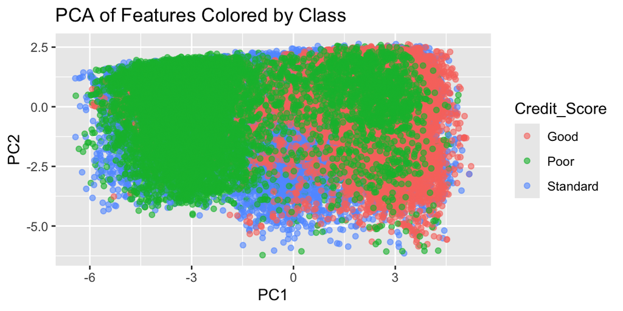

The PCA plot shows that the data has non-linear and overlapping class boundaries. Since QDA can model quadratic boundaries while LDA is limited to linear boundaries, QDA is likely a more suitable choice than LDA for this dataset.

**LASSO (Least Absolute Shrinkage and Selection Operator)** is applied to perform feature selection by shrinking the coefficients of less important (or insignificant) features to exactly zero, thereby removing them from the model. We used cv.glmnet() and family = “multinomial”, which is for multi-class classification, to perform LASSO regression with cross-validation. The cross-validation selects the best regularization parameter (λ) to minimize classification error. We extracted the coefficients of the model at lambda.1se, and identified the features with non-zero coefficients. Three features are removed after LASSO is applied.

```
## Original number of features: 37
##  Number of features after LASSO: 34
```

The final QDA model with LASSO achieved a macro `recall of 0.703`, `precision of 0.635`, `F1 score of 0.6365`, and an `AUC of 0.8363`, indicating good overall classification performance.

### 4.2 Support Vector Machine

**Support Vector Machine (SVM)** is a powerful algorithm for classification tasks. It finds the best boundary to separate different classes. For credit card grading, SVM is suitable due to its ability to handle complex patterns.

**RFE** with a custom **macro F1-score** was used to select features. This process identified **14 variables** that best support multi-class credit card classification.

Hyperparameters `C` and `sigma` were tuned using **five-fold cross-validated grid search**. A coarse grid was first applied to identify a rough parameter range, followed by a finer grid for improved precision. The finer grid used: `sigma = c(0.55, 0.6, 0.65)`,`C = c(1.1, 1.2, 1.3)`. To address **class imbalance**, **up-sampling** was applied during training. The **optimal parameters** determined from this process were `C = 1.2` and `sigma = 0.6`.

Using the optimal parameters, the SVM model was retrained on the training set. Evaluation on the test set yielded strong performance: `Macro Recall = 0.7057`, `Macro Precision = 0.7510`, `Macro F1 Score = 0.7239`, `Macro AUC = 0.8877`.

```r
#recursive feature elimination
library(doParallel)
# Define macro F1-score as customised summary function
f1_summary <- function(data, lev = NULL, model = NULL) {
  classes <- lev
  f1_scores <- sapply(classes, function(class) {
    tp <- sum(data$pred == class & data$obs == class)
    fp <- sum(data$pred == class & data$obs != class)
    fn <- sum(data$pred != class & data$obs == class)
    precision <- if ((tp + fp) == 0) 0 else tp / (tp + fp)
    recall <- if ((tp + fn) == 0) 0 else tp / (tp + fn)
    if ((precision + recall) == 0) 0 else 2 * precision * recall / (precision + recall)
  })
  f1_macro <- mean(f1_scores, na.rm = TRUE)
  names(f1_macro) <- "F1"
  return(f1_macro)
}
# Use rfFuncs as base and override summary function
f1Funcs <- rfFuncs
f1Funcs$summary <- f1_summary
# Set up parallel backend
cores <- 8
registerDoParallel(cores = cores)
# Prepare training data for RFE
data_train <- data.frame(X_train_scaled, Credit_Score = y_train)
# RFE control settings
set.seed(5003)
ctrl_f1 <- rfeControl(functions = f1Funcs, method = "cv", number = 5,
                      verbose = TRUE, allowParallel = TRUE)
# Run RFE to select top features based on macro F1
rfe_result <- rfe(
  x = data_train[, -ncol(data_train)],
  y = data_train$Credit_Score,
  sizes = 10:15,
  rfeControl = ctrl_f1
)
# Output selected features
print(rfe_result)
selected_vars <- predictors(rfe_result)
print(selected_vars)
# Stop parallel backend
stopImplicitCluster()

# hyperparameter tuning
# train SVM with cross-validation(F1)
# Define caret training control with upsampling and macro F1
ctrl_cv <- trainControl(method = "cv", number = 5, sampling = "up",
                        summaryFunction = f1_summary)
# Define parameter grid for SVM tuning
tune_grid <- expand.grid(sigma = (0.55, 0.6, 0.65), C = c(1.1, 1.2, 1.3)) #already determined a rough range by grid search
# Train SVM model with radial basis kernel
svm_model <- train(
  x = X_train_selected,
  y = y_train,
  method = "svmRadial",
  trControl = ctrl_cv,
  tuneGrid = tune_grid,
  metric = "F1"
)
# Show the best model and cross-validated results
print(svm_model)
```

```r
selected_vars <- c(
  "Delay_from_due_date", "Num_Credit_Card", "Changed_Credit_Limit",
  "Total_EMI_per_month", "Outstanding_Debt", "Monthly_Inhand_Salary",
  "Interest_Rate", "Annual_Income", "Age", "Num_of_Delayed_Payment",
  "Num_Bank_Accounts", "Num_Credit_Inquiries", "Monthly_Balance",
  "Credit_History_Age"
)
# Keep only selected features
X_train_selected <- X_train_scaled[, selected_vars]
X_test_selected  <- X_test_scaled[, selected_vars]

#use best params to train final model
svm_best_params <- expand.grid(sigma = 0.6, C = 1.2)

ctrl_final <- trainControl(method = "none",classProbs = TRUE)
#train final model
svm_final_model <- train(
  x = X_train_selected,
  y = y_train,
  method = "svmRadial",
  trControl = ctrl_final,
  tuneGrid = svm_best_params,
  metric = "F1"
)

# Evaluate
svm_y_pred <- predict(svm_final_model, newdata = X_test_selected)

# Generate confusion matrix and accuracy
svm_conf_matrix <- confusionMatrix(svm_y_pred, y_test)
svm_conf_matrix

# Extract confusion matrix table
svm_cm_table <- svm_conf_matrix$table
# 1. Per-class recall (sensitivity)
svm_recall_per_class <- diag(svm_cm_table) / colSums(svm_cm_table)
# 2. Per-class precision
svm_precision_per_class <- diag(svm_cm_table) / rowSums(svm_cm_table)
# 3. F1 per class
svm_f1_per_class <- 2 * svm_precision_per_class * svm_recall_per_class /
                (svm_precision_per_class + svm_recall_per_class)
#AUC
svm_y_prob <- predict(svm_final_model, newdata = X_test_selected, type = "prob")
y_true <- factor(y_test, levels = colnames(svm_y_prob))
svm_multi_roc <- multiclass.roc(response = y_true, predictor = as.matrix(svm_y_prob))
svm_auc_value <- as.numeric(svm_multi_roc$auc)

# 4. Macro averages
macro_svm_recall <- mean(svm_recall_per_class, na.rm = TRUE)
macro_svm_precision <- mean(svm_precision_per_class, na.rm = TRUE)
macro_svm_f1 <- mean(svm_f1_per_class, na.rm = TRUE)

# Print
cat("Macro SVM_Recall   :", round(macro_svm_recall, 4), "\n")
cat("Macro SVM_Precision:", round(macro_svm_precision, 4), "\n")
cat("Macro SVM_F1 Score :", round(macro_svm_f1, 4), "\n")
cat("Macro SVM_AUC      :", round(svm_auc_value, 4), "\n")
```

### 4.3 k-Nearest Neighbours

**k-Nearest Neighbors (kNN)** is a classic non-parametric classification algorithm in statistics. The choice of the number of neighbors, `k`, has a direct and significant impact on model performance.

This experiment used a **grid search strategy** with three representative values of `k = 3`, `k = 5`, and `k = 10`, corresponding to small, medium, and large neighborhood sizes.

- A **smaller `k`** (e.g., `k = 3`) makes the model more sensitive to local structures and better at capturing fine-grained differences, but it may be more susceptible to noise, leading to **overfitting**.
- A **larger `k`** (e.g., `k = 10`) results in a smoother model with greater robustness but can cause **underfitting**.
- `k = 5` provides a balance between bias and variance and is often used as a default or baseline value.

The goal of this tuning was to find the value of `k` that achieves the best generalization performance on the test set.

```r
# Train kNN classifier
# Define the grid of k values to try
knn_grid <- expand.grid(k = c(3, 5, 10))

# Define training control with 5-fold cross-validation
ctrl <- trainControl(method = "cv", number = 5)

# Train the KNN model
set.seed(5003)
knn_model <- train(
  x = X_train_scaled,
  y = y_train,
  method = "knn",
  trControl = ctrl,
  tuneGrid = knn_grid,
  metric = "Accuracy"
)
# Evaluate
y_pred <- predict(knn_model, newdata = X_test_scaled)

# Generate confusion matrix and accuracy
conf_matrix <- confusionMatrix(y_pred, y_test)
conf_matrix

# Extract confusion matrix table
cm_table <- conf_matrix$table

# 1. Per-class recall (sensitivity)
recall_per_class <- diag(cm_table) / colSums(cm_table)

# 2. Per-class precision
precision_per_class <- diag(cm_table) / rowSums(cm_table)

# 3. F1 per class
f1_per_class <- 2 * precision_per_class * recall_per_class /
                (precision_per_class + recall_per_class)

# 4.AUC
y_prob <- predict(knn_model, newdata = X_test_scaled, type = "prob")
y_true <- factor(y_test, levels = colnames(y_prob))
multi_roc <- multiclass.roc(response = y_true, predictor = as.matrix(y_prob))
auc_value <- as.numeric(multi_roc$auc)


# 4. Macro averages
macro_knn_recall <- mean(recall_per_class, na.rm = TRUE)
macro_knn_precision <- mean(precision_per_class, na.rm = TRUE)
macro_knn_f1 <- mean(f1_per_class, na.rm = TRUE)

# Print
cat("KNN_Accuracy       :", round(conf_matrix$overall["Accuracy"], 4), "\n")
cat("Macro KNN_AUC      :", round(auc_value, 4), "\n")
cat("Macro KNN_Recall   :", round(macro_knn_recall, 4), "\n")
cat("Macro KNN_Precision:", round(macro_knn_precision, 4), "\n")
cat("Macro KNN_F1 Score :", round(macro_knn_f1, 4), "\n")
```

| Model | Accuracy | Macro_AUC | Macro_Recall | Macro_Precision | Macro_F1 |
| --- | --- | --- | --- | --- | --- |
| Default_KNN | 0.6756 | 0.8171 | 0.6262 | 0.6453 | 0.6345 |
| Tuned_KNN | 0.6847 | 0.8321 | 0.6341 | 0.6571 | 0.6438 |

### 4.4 Multinomial Logistic Regression

Multinomial logistic Regression (MLR) is an extension of binary logistic regression to multi-class classification. In this task, MLR can predict the probabilities of each credit rating based on individual characteristics such as credit history, income level, and repayment record through the softmax function, thereby achieving classification prediction.

MLR offers strong interpretability both in its model structure and prediction results. For the model itself, examining the regression coefficients for different classes allows us to assess the direction and relative strength of each feature’s influence on classification results, thereby clarifying the role of variables in the model. For prediction results, MLR not only predicts the most likely class but also provides the probability distribution over all classes, which can assist stakeholders in making business decisions. Therefore, although logistic regression assumes a strong linear relationship between features and the target, we still choose it as one of the models for this classification task.

Stepwise selection with both directions was applied to perform feature selection and 5-fold cross-validation was used to evaluate the performance of both the full and the simplified models. Compared with dimensionality reduction or regularization methods such as PCA or Lasso, stepwise selection better preserves the interpretability of individual features, making the model more explainable. And the evaluation results showed that the simplified model maintained strong predictive performance while achieving a more concise structure. Therefore, we selected the simplified model as the final MLR model.

```r
set.seed(1)
library(MASS)

# Set up 5-fold cross-validation
ctrl <- trainControl(method = "cv", number = 5, classProbs = TRUE,
summaryFunction = multiClassSummary)

# Train full multinomial logistic regression model with 5-fold CV
mlr_full_cv <- train(Credit_Score ~ ., data = data.frame(Credit_Score = y_train, X_train_scaled_mlr), method = "multinom", trControl = ctrl, trace = FALSE, metric = 'AUC',tuneGrid = expand.grid(decay = 0))

# Select variables using stepwise regression
step_both <- MASS::stepAIC(multinom(Credit_Score ~ ., data = data.frame(Credit_Score = y_train, X_train_scaled_mlr)), direction = "both", trace = FALSE)

# Obtain the name of variables
step_both_vars <- attr(terms(step_both), "term.labels")
formula_both <- as.formula(paste("Credit_Score ~", paste(step_both_vars, collapse = "+")))

# Train new model with selected variables
mlr_stepboth_cv <- train(formula_both, data = data.frame(Credit_Score = y_train, X_train_scaled_mlr), method = "multinom", trControl = ctrl, metric ='AUC', trace = FALSE,tuneGrid = expand.grid(decay = 0))

# Compare models' performance
mlr_full_cv$results
mlr_stepboth_cv$results

# Use the selected features to train the final MLR model
x_train_step <- X_train_scaled_mlr[, c(step_both_vars)]
x_test_step <- X_test_scaled_mlr[, c(step_both_vars)]
mlr_model <- multinom(Credit_Score ~ ., data = data.frame(Credit_Score = y_train, x_train_step))

# Evaluate the final model
mlr_pred <- predict(mlr_model, newdata = x_test_step)

# Generate MLR confusion matrix
mlr_conf_matrix <- confusionMatrix(mlr_pred,y_test)

# Extract MLR confusion matrix table
mlr_cm_table <- mlr_conf_matrix$table
# 1. Per-class recall (sensitivity)
mlr_recall_per_class <- diag(mlr_cm_table) / colSums(mlr_cm_table)
# 2. Per-class precision
mlr_precision_per_class <- diag(mlr_cm_table) / rowSums(mlr_cm_table)
# 3. F1 per class
mlr_f1_per_class <- 2 * mlr_precision_per_class * mlr_recall_per_class /
                (mlr_precision_per_class + mlr_recall_per_class)
# 4. AUC
mlr_y_prob <- predict(mlr_model, newdata = x_test_step, type = "prob")
y_true <- factor(y_test, levels = colnames(mlr_y_prob))
mlr_multi_roc <- multiclass.roc(response = y_true, predictor = as.matrix(mlr_y_prob))
mlr_auc_value <- as.numeric(mlr_multi_roc$auc)
# 5. Macro averages
macro_mlr_recall <- mean(mlr_recall_per_class, na.rm = TRUE)
macro_mlr_precision <- mean(mlr_precision_per_class, na.rm = TRUE)
macro_mlr_f1 <- mean(mlr_f1_per_class, na.rm = TRUE)
# Print
cat("Macro MLR_Recall   :", round(macro_mlr_recall, 4), "\n")
cat("Macro MLR_Precision:", round(macro_mlr_precision, 4), "\n")
cat("Macro MLR_F1 Score :", round(macro_mlr_f1, 4), "\n")
cat("Macro MLR_AUC :", round(mlr_auc_value, 4), "\n")
```

| Model | Num_Features | Macro_Recall | Macro_Precision | Macro_F1 | Macro_AUC |
| --- | --- | --- | --- | --- | --- |
| Full Model | 21 | 0.6285 | 0.6469 | 0.6357 | 0.825 |
| Simplified Model | 17 | 0.6310 | 0.6499 | 0.6386 | 0.832 |

### 4.5 Extreme Gradient Boosting (XGBoost)

Extreme Gradient Boosting (XGBoost) is a powerful gradient-boosted decision tree algorithm widely used for classification tasks. It builds a sequence of trees to correct errors from previous iterations, enabling strong predictive performance on structured datasets such as credit grading. Hyperparameters were tuned using forward selection with cross-validation based on AUC. Initial coarse tuning helped identify a promising region of the hyperparameter space, followed by fine adjustment. The final parameter set was: eta = 0.3, max_depth = 8, min_child_weight = 3, subsample = 0.9, colsample_bytree = 0.5, and gamma = 1.

```r
# XGBoost
# data preparing
label_map <- as.integer(y_train) - 1  # XGBoost request labels start at 0
dtrain <- xgb.DMatrix(data = as.matrix(X_train_scaled), label = label_map)
dtest <- xgb.DMatrix(data = as.matrix(X_test_scaled))
num_class <- length(levels(y_train))

# train model
set.seed(5003)
xgb_model <- xgboost(
  data = dtrain,
  objective = "multi:softprob",
  num_class = num_class,
  nrounds = 100,
  max_depth = 6,
  eta = 0.1,
  verbose = 0
)

# predict probability
xgb_prob <- predict(xgb_model, newdata = dtest)
xgb_prob <- matrix(xgb_prob, ncol = num_class, byrow = TRUE)
colnames(xgb_prob) <- levels(y_train)

# predict classification
xgb_pred <- factor(colnames(xgb_prob)[max.col(xgb_prob)], levels = levels(y_train))

# evaluation matrix
xgb_metrics <- evaluate_metrics(y_test, xgb_pred, xgb_prob, levels(y_train))
# cat("Macro XGB_Recall   :", round(xgb_metrics$Macro_Recall, 4), "\n")
# cat("Macro XGB_Precision:", round(xgb_metrics$Macro_Precision, 4), "\n")
# cat("Macro XGB_F1 Score :", round(xgb_metrics$Macro_F1, 4), "\n")
# cat("Macro XGB_AUC      :", round(xgb_metrics$Macro_AUC, 4), "\n")

# direct run fix hyperparameters result

# Convert labels to numeric [0, 1, 2] for xgboost
y_train_num <- as.integer(y_train) - 1
y_test_num <- as.integer(y_test) - 1

# Create DMatrix
dtrain <- xgb.DMatrix(data = as.matrix(X_train_scaled), label = y_train_num)
dtest <- xgb.DMatrix(data = as.matrix(X_test_scaled), label = y_test_num)

# Set fixed hyperparameters
final_params <- list(
  objective = "multi:softprob",
  eval_metric = "mlogloss",
  num_class = length(unique(y_train_num)),
  eta = 0.3,
  max_depth = 8,
  min_child_weight = 3,
  subsample = 0.9,
  colsample_bytree = 0.5,
  gamma = 1
)

# Reset random seed
set.seed(5003)

# Train model
xgb_model <- xgboost(
  params = final_params,
  data = dtrain,
  nrounds = 100,
  verbose = 0
)

# Predict probability and convert to matrix
xgb_prob <- predict(xgb_model, newdata = dtest)
xgb_prob <- matrix(xgb_prob, ncol = final_params$num_class, byrow = TRUE)
colnames(xgb_prob) <- levels(y_train)

# Predict class labels
xgb_pred <- factor(colnames(xgb_prob)[max.col(xgb_prob)], levels = levels(y_train))

# Confusion matrix visualization
XGB_conf_matrix <- table(Predicted = xgb_pred, Reference = y_test)
conf_df <- as.data.frame(XGB_conf_matrix)
colnames(conf_df) <- c("Prediction", "Reference", "Freq")


# Evaluate performance
final_xgb_metrics <- evaluate_metrics(y_test, xgb_pred, xgb_prob, levels(y_train))

xgb_metrics1 <- xgb_metrics
xgb_metrics2 <- final_xgb_metrics
xgb_comparison_table <- data.frame(
  Model = c("Default_Model", "Tuned_Model"),
  Macro_Recall = round(c(xgb_metrics1$Macro_Recall, xgb_metrics2$Macro_Recall), 4),
  Macro_Precision = round(c(xgb_metrics1$Macro_Precision, xgb_metrics2$Macro_Precision), 4),
  Macro_F1 = round(c(xgb_metrics1$Macro_F1, xgb_metrics2$Macro_F1), 4),
  Macro_AUC = round(c(xgb_metrics1$Macro_AUC, xgb_metrics2$Macro_AUC), 4)
)

kable(xgb_comparison_table, align = "c", caption = "Comparison of XGBoost Models") %>%
  kable_styling(bootstrap_options = c("striped", "hover", "condensed", "responsive")) %>%
  column_spec(1, bold = TRUE, color = "black", background = "#ecf0f1") %>% ##3498db
  row_spec(0, bold = TRUE, background = "#ecf0f1")
```

```r
#cross-validation for XGBoost

set.seed(5003)

# Convert labels to numeric [0, 1, 2] for xgboost
y_train_num <- as.integer(y_train) - 1
y_test_num <- as.integer(y_test) - 1

# Create DMatrix
dtrain <- xgb.DMatrix(data = as.matrix(X_train_scaled), label = y_train_num)
dtest <- xgb.DMatrix(data = as.matrix(X_test_scaled), label = y_test_num)

# Flag to enable/disable tuning
FIND_OPTIMAL_PARAMS <- TRUE

if (FIND_OPTIMAL_PARAMS) {
  base_config <- list(
    objective = "multi:softprob",
    eval_metric = "auc",
    num_class = length(unique(y_train_num))
  )

  search_spaces <- list(
    eta = c(0.05, 0.1, 0.2, 0.3),
    max_depth = c(4, 5, 7, 8),
    min_child_weight = c(2, 3, 4, 5),
    subsample = c(0.5, 0.7, 0.9),
    colsample_bytree = c(0.5, 0.7, 0.9),
    gamma = c(1, 2, 3)
  )

  # Greedy forward tuning
  forward_select <- function(config, space, name) {
    top_auc <- -Inf
    best_val <- NULL
    for (val in space) {
      config[[name]] <- val
      cv_out <- xgb.cv(
        params = config,
        data = dtrain,
        nrounds = 300,
        nfold = 5,
        early_stopping_rounds = 10,
        maximize = TRUE,
        verbose = 0
      )
      auc_score <- max(cv_out$evaluation_log$test_auc_mean)
      if (auc_score > top_auc) {
        top_auc <- auc_score
        best_val <- val
      }
    }
    config[[name]] <- best_val
    return(config)
  }

  for (key in names(search_spaces)) {
    base_config <- forward_select(base_config, search_spaces[[key]], key)
  }

  cat("Tuned Parameters:\n")
  print(base_config)
}

# Final param set
final_params <- if (FIND_OPTIMAL_PARAMS) base_config else list(
  objective = "multi:softprob",
  eval_metric = "auc",
  num_class = length(unique(y_train_num)),
  max_depth = 8,
  eta = 0.2,
  gamma = 2,
  min_child_weight = 3,
  subsample = 0.9,
  colsample_bytree = 0.6
)

# Run cross-validation
cv_results <- xgb.cv(
  params = final_params,
  data = dtrain,
  nrounds = 200,
  nfold = 5,
  early_stopping_rounds = 10,
  maximize = TRUE,
  print_every_n = 1,
  verbose = 0
)

# Visualize AUC over iterations
eval_log <- cv_results$evaluation_log
eval_log$iter <- seq_len(nrow(eval_log))
```

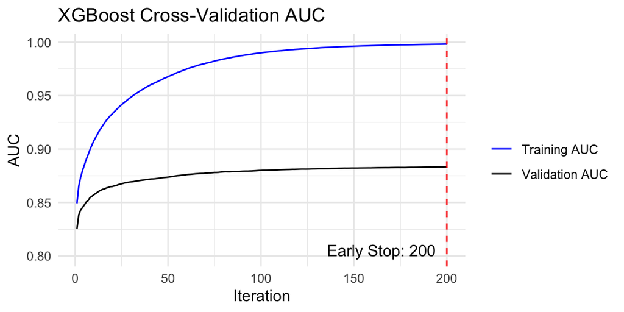

Comparison of XGBoost Models

[output not shown]

```r
ggplot(eval_log) +
  geom_line(aes(x = iter, y = train_auc_mean, color = "Training AUC")) +
  geom_line(aes(x = iter, y = test_auc_mean, color = "Validation AUC")) +
  geom_vline(xintercept = cv_results$best_iteration, linetype = "dashed", color = "red") +
  annotate("text", x = cv_results$best_iteration, y = 0.8,
           label = paste("Early Stop:", cv_results$best_iteration), hjust = 1.1, vjust = 0) +
  labs(title = "XGBoost Cross-Validation AUC",
       x = "Iteration", y = "AUC", color = "") +
  scale_color_manual(values = c("Training AUC" = "blue", "Validation AUC" = "black")) +
  theme_minimal()
```

## 5. Performance Evaluation

### 5.1 Confusion Matrices

We used five optimized models to make predictions on the test set and generated the corresponding confusion matrices. The confusion matrix provides an intuitive view of model performance: each row represents the predicted classes, while each column represents the actual classes. By comparing the confusion matrices across models, we can better understand their classification abilities for each credit rating category.

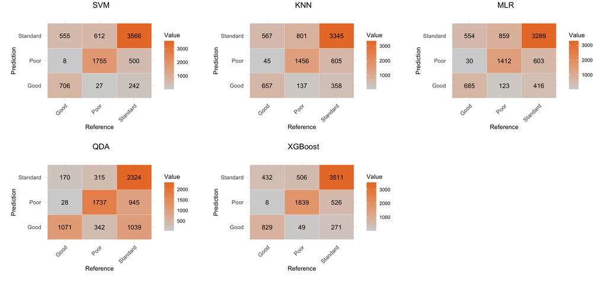

```r
# Load required libraries
library(ggplot2)
library(gridExtra)
library(grid)
library(tidyr)

# Define a common theme function for optimized display
theme_confusion <- function() {
  theme_minimal() +
  theme(
    axis.text.x = element_text(angle = 45, hjust = 1, size = 10),
    axis.text.y = element_text(size = 10),
    plot.margin = unit(c(20, 20, 20, 20), "pt")
  )
}

# The confusion matrices and evaluation metrics of the five models were hard-coded using precomputed results to reduce computational overhead.
# SVM confusion matrix data
svm_cm <- matrix(c(
  706, 27, 242,
  8, 1755, 500,
  555, 612, 3566
), nrow = 3, byrow = TRUE)

colnames(svm_cm) <- c("Good", "Poor", "Standard")
rownames(svm_cm) <- c("Good", "Poor", "Standard")
svm_df <- as.data.frame(svm_cm)
svm_df$Prediction <- rownames(svm_cm)
svm_df <- tidyr::pivot_longer(svm_df, cols = c("Good", "Poor", "Standard"),
                              names_to = "Reference", values_to = "Value")
svm_fig <- ggplot(svm_df, aes(x = Reference, y = Prediction, fill = Value)) +
  geom_tile(color = "white") +
  geom_text(aes(label = Value), vjust = 0.5, size = 4) +
  scale_fill_gradient(low = "#D3D3D3", high = "#EA7B30") +
  theme_confusion()

# KNN confusion matrix data
knn_cm <- matrix(c(
  657, 137, 358,
  45, 1456, 605,
  567, 801, 3345
), nrow = 3, byrow = TRUE)
colnames(knn_cm) <- c("Good", "Poor", "Standard")
rownames(knn_cm) <- c("Good", "Poor", "Standard")
knn_df <- as.data.frame(knn_cm)
knn_df$Prediction <- rownames(knn_cm)
knn_df <- tidyr::pivot_longer(knn_df, cols = c("Good", "Poor", "Standard"),
                              names_to = "Reference", values_to = "Value")
knn_fig <- ggplot(knn_df, aes(x = Reference, y = Prediction, fill = Value)) +
  geom_tile(color = "white") +
  geom_text(aes(label = Value), vjust = 0.5, size = 4) +
  scale_fill_gradient(low = "#D3D3D3", high = "#EA7B30") +
  theme_confusion()

# MLR confusion matrix data
mlr_cm <- matrix(c(
  685, 123, 416,
   30, 1412, 603,
  554, 859, 3289
), nrow = 3, byrow = TRUE)
colnames(mlr_cm) <- c("Good", "Poor", "Standard")
rownames(mlr_cm) <- c("Good", "Poor", "Standard")
mlr_df <- as.data.frame(mlr_cm)
mlr_df$Prediction <- rownames(mlr_cm)
mlr_df <- tidyr::pivot_longer(mlr_df, cols = c("Good", "Poor", "Standard"),
                              names_to = "Reference", values_to = "Value")
mlr_fig <- ggplot(mlr_df, aes(x = Reference, y = Prediction, fill = Value)) +
  geom_tile(color = "white") +
  geom_text(aes(label = Value), vjust = 0.5, size = 4) +
  scale_fill_gradient(low = "#D3D3D3", high = "#EA7B30") +
  theme_confusion()

# QDA confusion matrix data
qda_cm <- matrix(c(
  1071, 342, 1039,
  28, 1737, 945,
  170, 315, 2324
), nrow = 3, byrow = TRUE)

colnames(qda_cm) <- c("Good", "Poor", "Standard")
rownames(qda_cm) <- c("Good", "Poor", "Standard")
qda_df <- as.data.frame(qda_cm)
qda_df$Prediction <- rownames(qda_cm)
qda_df <- tidyr::pivot_longer(qda_df, cols = c("Good", "Poor", "Standard"),
                              names_to = "Reference", values_to = "Value")
qda_fig <- ggplot(qda_df, aes(x = Reference, y = Prediction, fill = Value)) +
  geom_tile(color = "white") +
  geom_text(aes(label = Value), vjust = 0.5, size = 4) +
  scale_fill_gradient(low = "#D3D3D3", high = "#EA7B30") +
  theme_confusion()

# XGBoost confusion matrix data (keeping original values)
xgb_cm <- matrix(c(
  829, 49, 271,
  8, 1839, 526,
  432, 506, 3511
), nrow = 3, byrow = TRUE)
colnames(xgb_cm) <- c("Good", "Poor", "Standard")
rownames(xgb_cm) <- c("Good", "Poor", "Standard")
xgb_df <- as.data.frame(xgb_cm)
xgb_df$Prediction <- rownames(xgb_cm)
xgb_df <- tidyr::pivot_longer(xgb_df, cols = c("Good", "Poor", "Standard"),
                              names_to = "Reference", values_to = "Value")
xgb_fig <- ggplot(xgb_df, aes(x = Reference, y = Prediction, fill = Value)) +
  geom_tile(color = "white") +
  geom_text(aes(label = Value), vjust = 0.5, size = 4) +
  scale_fill_gradient(low = "#D3D3D3", high = "#EA7B30") +
  theme_confusion()

# Change 2x3 layout to 3x2 layout
print(grid.arrange(
  arrangeGrob(svm_fig, top = textGrob("SVM", gp = gpar(fontsize = 14))),
  arrangeGrob(knn_fig, top = textGrob("KNN", gp = gpar(fontsize = 14))),
  arrangeGrob(mlr_fig, top = textGrob("MLR", gp = gpar(fontsize = 14))),
  arrangeGrob(qda_fig, top = textGrob("QDA", gp = gpar(fontsize = 14))),
  arrangeGrob(xgb_fig, top = textGrob("XGBoost", gp = gpar(fontsize = 14))),
  ncol = 3, nrow = 2
))
```

### 5.2 Performance

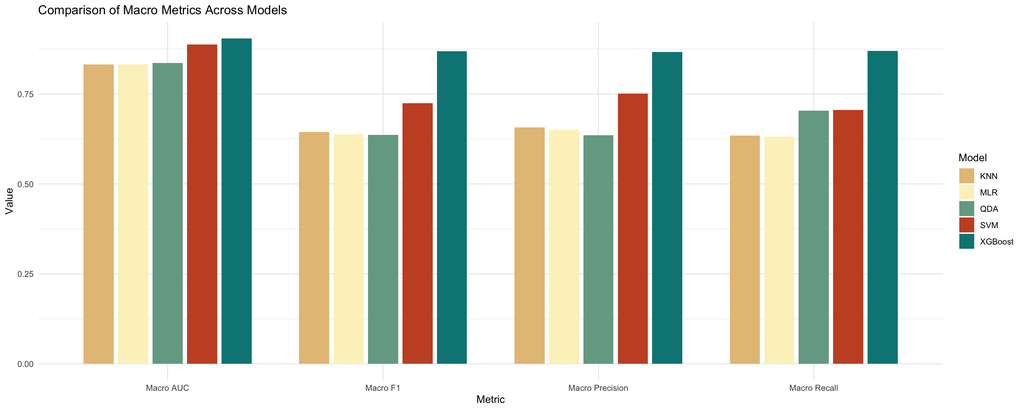

## 6. Conclusion

### 6.1 Limitation

Due to the large size of the training set and the limited computational capacity of our devices, performing a full grid search to identify globally optimal hyperparameters was computationally infeasible for complex models such as XGBoost and SVM.

Despite the large scale of the dataset and the use of hierarchical cross-validation, these models still show performance gaps when dealing with imbalanced classes. The recall rates and F1 scores of ‘Good’ and ‘Poor’ have always been low, which may affect the model’s ability to learn the generalization patterns of these categories. Although the overall accuracy rate and macro indicators are satisfactory, the model’s sensitivity to underrepresented categories remains a challenge.

Furthermore, the interpretability of complex models such as XGBoost is limited, which makes it difficult to extract clear insights solely based on feature importance.

### 6.2 Conclusion

This project is centered around the credit scoring dataset on Kaggle, aiming to construct a multi-classification model to identify users’ credit ratings, namely `Good`, `Standard`, and `Poor`, thereby providing a decision-making basis for the risk control and customer stratification of financial institutions. Starting from data cleaning, the project adopts various preprocessing strategies such as median filling for missing values, IQR detecting outliers, and re-coding of categorical variables, effectively improving data quality and modeling robustness.

To sum up, **XGBoost** is the best model choice for the current task and is suitable for deployment in actual financial risk control scenarios. For future improvements, we will focus on enhancing the predictive capabilities of minority classes (such as the Good class) through techniques like oversampling, category weighting, or ensemble methods. In addition, explore hyperparameter tuning and feature engineering to further enhance the `AUC` and `F1` scores of all models, especially **XGBoost**.

## 7. Reference

Ji, S. & Xie, Y. (n.d.). Logistic Regression: From Binary to Multi-Class. [online] https://people.tamu.edu/~sji/classes/LR.pdf.

Paris, R. (2021). Credit score classification [Data set]. Kaggle. https://www.kaggle.com/datasets/parisrohan/credit-score-classification

## Acknowledgements

This document incorporates writing assistance, code suggestions, and formatting support generated using ChatGPT by OpenAI. The use of AI aimed to improve clarity and efficiency, while all analytical decisions and interpretations remain the responsibility of the author.